# Analysis of Multi-view and Multi-modal Classification Approaches: Quantitative analysis

### 3.1.2 Distribution of different metrics types in papers

We investigate how many papers use a given type of indicator. Distribution of unique papers reporting at least one result for the selected indicator, i.e. how many unique papers (bibtex keys) reported each indicator.

```r
unique_data_clean <- data_clean %>%
  # drop any rows with missing bibtex if those are “unnamed” data:
  filter(!is.na(bibtex)) %>%
  # one row per work
  group_by(bibtex) %>%
  # for each indicator, check if ANY non-NA appears
  summarise(across(all_of(indicators), ~ any(!is.na(.)), .names = "used_{.col}")) %>%
  ungroup() %>%
  # now count how many works used each one
  summarise(across(starts_with("used_"), ~ sum(.), .names = "{.col}"))
```

```r
knitr::kable(unique_data_clean, caption = "Distribution of unique works reporting at least one result for the selected indicator") %>% kableExtra::kable_styling()
```

Table 3.3: Table 3.4: Distribution of unique works reporting at least one result for the selected indicator

| used_acc.view.single.text | used_acc.view.combinations.text | used_prec.view.single.text | used_prec.view.combinations.text | used_rec.view.single.text | used_rec.view.combinations.text | used_f1score.view.single.text | used_f1score.view.combinations.text |
| --- | --- | --- | --- | --- | --- | --- | --- |
| 20 | 20 | 5 | 5 | 6 | 6 | 17 | 18 |

Distribution of works reporting one or more results (values) for the selected indicator:

- measurement_counts is a table of (bibtex, n_measures) telling us for each bibtex how many different values are actually reported by the given indicators.

```r
# Fill down the bibtex so each measurement row knows its paper
data_filled <- data_clean %>%
  fill(.data[['bibtex']], .direction = "down")
```

```r
# Count measurements per paper × indicator
measurement_counts <- data_filled %>%
  # now every row has a bibtex, so no need to filter(!is.na)
  group_by(bibtex) %>%
  summarise(across(all_of(indicators), ~ sum(!is.na(.)), .names = "n_{.col}")) %>%
  ungroup() %>%
  filter(if_any(starts_with("n_"), ~ . > 0))
```

```r
knitr::kable(measurement_counts, caption = "Distribution of extracted indicators values per papers") %>% kableExtra::kable_styling()
```

Table 3.5: Table 3.6: Distribution of extracted indicators values per papers

| bibtex | n_acc.view.single.text | n_acc.view.combinations.text | n_prec.view.single.text | n_prec.view.combinations.text | n_rec.view.single.text | n_rec.view.combinations.text | n_f1score.view.single.text | n_f1score.view.combinations.text |
| --- | --- | --- | --- | --- | --- | --- | --- | --- |
| akhtiamov2019 | 0 | 0 | 0 | 0 | 1 | 1 | 0 | 0 |
| aminim2009 | 6 | 6 | 0 | 0 | 0 | 0 | 6 | 6 |
| aminim2010 | 0 | 0 | 0 | 0 | 0 | 0 | 48 | 48 |
| aminim2010b | 6 | 6 | 0 | 0 | 0 | 0 | 6 | 6 |
| bhatt2019 | 2 | 2 | 0 | 0 | 0 | 0 | 0 | 0 |
| carmona2020 | 2 | 2 | 0 | 0 | 0 | 0 | 2 | 2 |
| chens2019 | 0 | 0 | 12 | 12 | 0 | 0 | 0 | 0 |
| dasigiv2001 | 0 | 0 | 4 | 4 | 4 | 4 | 0 | 0 |
| fakri2015 | 12 | 12 | 0 | 0 | 0 | 0 | 12 | 12 |
| fengz2024 | 0 | 0 | 0 | 0 | 0 | 0 | 6 | 6 |
| ferreira2018 | 9 | 9 | 0 | 0 | 0 | 0 | 0 | 0 |
| ghorbanali2024 | 2 | 2 | 0 | 0 | 0 | 0 | 2 | 2 |
| graffm2023 | 0 | 0 | 0 | 0 | 0 | 0 | 1 | 1 |
| gui2021 | 1 | 1 | 0 | 0 | 1 | 1 | 1 | 1 |
| gup2009 | 0 | 0 | 0 | 0 | 0 | 0 | 0 | 2 |
| guptad2018 | 0 | 0 | 0 | 0 | 0 | 0 | 1 | 1 |
| hoylea2019 | 9 | 9 | 0 | 0 | 0 | 0 | 0 | 0 |
| huz2017 | 0 | 0 | 1 | 1 | 1 | 1 | 1 | 1 |
| iglesias2016 | 0 | 0 | 0 | 0 | 0 | 0 | 2 | 2 |
| jiz2024 | 5 | 5 | 0 | 0 | 0 | 0 | 5 | 5 |
| karisanip2022 | 0 | 0 | 2 | 2 | 2 | 2 | 2 | 2 |
| liuw2021 | 0 | 0 | 3 | 3 | 3 | 3 | 3 | 3 |
| longg2013 | 3 | 3 | 0 | 0 | 0 | 0 | 0 | 0 |
| luox2022 | 6 | 6 | 0 | 0 | 0 | 0 | 1 | 1 |
| max2020 | 1 | 1 | 0 | 0 | 0 | 0 | 0 | 0 |
| perinaa2013 | 3 | 3 | 0 | 0 | 0 | 0 | 0 | 0 |
| sangy2022 | 9 | 9 | 0 | 0 | 0 | 0 | 0 | 0 |
| varmanp2023 | 1 | 1 | 0 | 0 | 0 | 0 | 0 | 0 |
| wangh2019 | 2 | 2 | 0 | 0 | 0 | 0 | 0 | 0 |
| xuh2016 | 12 | 12 | 0 | 0 | 0 | 0 | 0 | 0 |
| xux2016 | 4 | 4 | 0 | 0 | 0 | 0 | 0 | 0 |
| zhang2021 | 6 | 6 | 0 | 0 | 0 | 0 | 0 | 0 |
| zhangx2010b | 0 | 0 | 0 | 0 | 0 | 0 | 1 | 1 |

We have 33 unique papers.

Compute overall totals and summary statistics on “total measurements per paper” (i.e. summing across all indicators).

```r
#  Overall totals & stats across *all* indicators per paper
total_stats <- measurement_counts %>%
  mutate(total_per_paper = rowSums(across(starts_with("n_")))) %>%
  summarise(
    n_papers    = n(),
    grand_total = sum(total_per_paper),
    mean        = mean(total_per_paper),
    sd          = sd(total_per_paper),
    median      = median(total_per_paper),
    min         = min(total_per_paper),
    max         = max(total_per_paper)
  )
```

```r
knitr::kable(total_stats, caption = "Global distribution and statistics") %>% kableExtra::kable_styling()
```

Table 3.7: Table 3.8: Global distribution and statistics

| n_papers | grand_total | mean | sd | median | min | max |
| --- | --- | --- | --- | --- | --- | --- |
| 33 | 472 | 14.30303 | 17.735 | 8 | 2 | 96 |

Summarise those counts across papers to get the total number of measurements per indicator and statistics (mean, sd, median, etc.)

```r
# Per-indicator summary across papers
indicator_stats <- measurement_counts %>%
  pivot_longer(cols      = starts_with("n_"),
               names_to  = "indicator",
               values_to = "n_measures") %>%
  group_by(indicator) %>%
  summarise(
    papers_reported   = sum(n_measures >  0),
    total_measures  = sum(n_measures),
    mean_per_paper    = mean(n_measures),
    sd_per_paper      = sd(n_measures),
    median_per_paper  = median(n_measures),
    min_per_paper     = min(n_measures),
    max_per_paper    = max(n_measures),
    .groups = "drop"
  ) %>%
  arrange(desc(total_measures))
```

```r
knitr::kable(indicator_stats, caption = "Distribution of indicators in all works") %>% kableExtra::kable_styling()
```

Table 3.9: Table 3.10: Distribution of indicators in all works

| indicator | papers_reported | total_measures | mean_per_paper | sd_per_paper | median_per_paper | min_per_paper | max_per_paper |
| --- | --- | --- | --- | --- | --- | --- | --- |
| n_f1score.view.combinations.text | 18 | 102 | 3.0909091 | 8.4792528 | 1 | 0 | 48 |
| n_acc.view.combinations.text | 20 | 101 | 3.0606061 | 3.7244076 | 2 | 0 | 12 |
| n_acc.view.single.text | 20 | 101 | 3.0606061 | 3.7244076 | 2 | 0 | 12 |
| n_f1score.view.single.text | 17 | 100 | 3.0303030 | 8.4944278 | 1 | 0 | 48 |
| n_prec.view.combinations.text | 5 | 22 | 0.6666667 | 2.2314046 | 0 | 0 | 12 |
| n_prec.view.single.text | 5 | 22 | 0.6666667 | 2.2314046 | 0 | 0 | 12 |
| n_rec.view.combinations.text | 6 | 12 | 0.3636364 | 0.9293204 | 0 | 0 | 4 |
| n_rec.view.single.text | 6 | 12 | 0.3636364 | 0.9293204 | 0 | 0 | 4 |

## 3.2 Pseudoreplication: Naive approaches to comparision multiview and single view results

The analysis below is only an introduction to the more in-depth analysis presented later in the article, performed using aggregated means and medians per work and meta-analysis.

### 3.2.1 Distribution of metrics values in papers

```r
long_df <- melt(data_clean[indicators],
                variable.name = "variable",
                value.name    = "value")
```

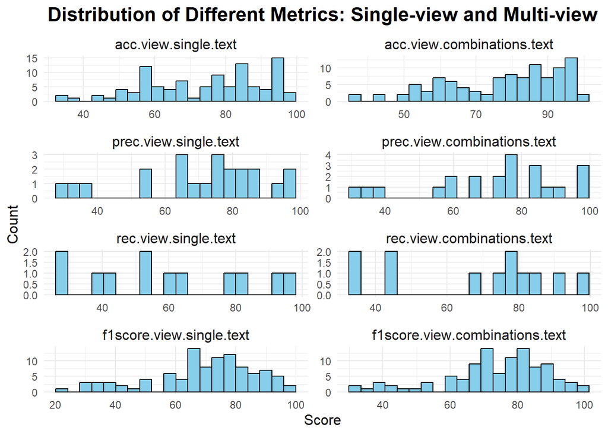

```r
gplot <- ggplot(long_df, aes(x = value)) +
  geom_histogram(bins = 20,
                 fill = "skyblue",
                 color = "black") +
  facet_wrap(~ variable,
             scales = "free",
             nrow   = 4,
             ncol   = 2) +
  labs(title = "Distribution of Different Metrics: Single-view and Multi-view",
       x     = "Score",
       y     = "Count") +
  theme_minimal() +
  theme(
    plot.title        = element_text(hjust = 0.5, size = 16, face = "bold"),
    strip.text        = element_text(size = 12),
    axis.title        = element_text(size = 12),
    panel.spacing     = unit(0.5, "lines")
  )

gplot
```

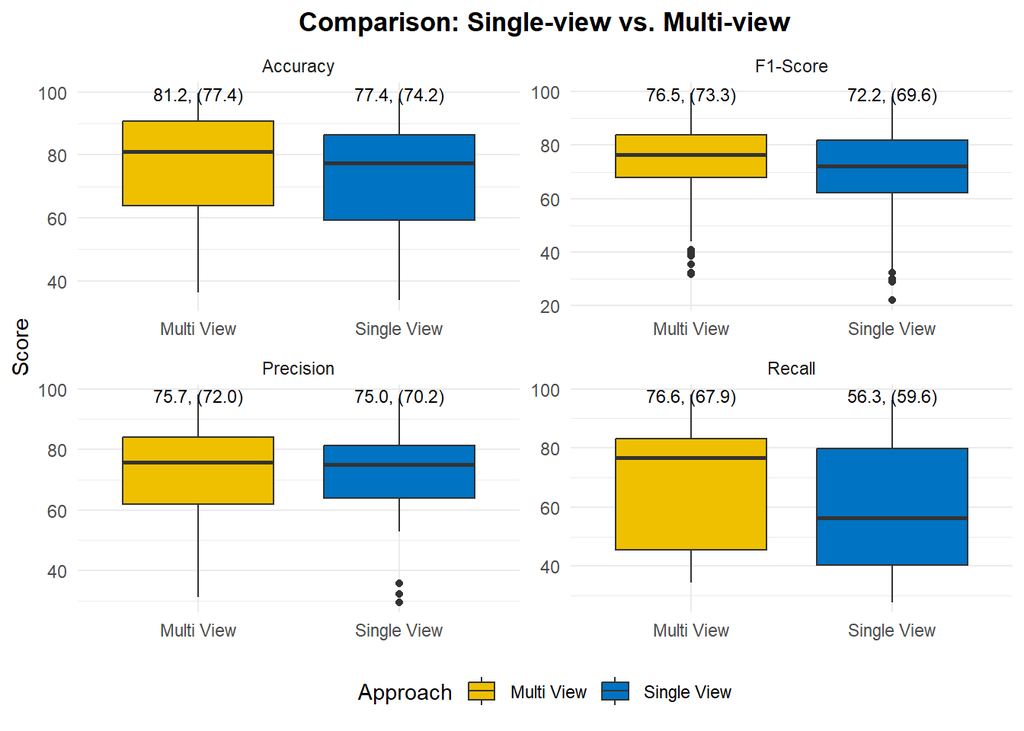

```r
# Bind data into a single data‐frame
plot_df <- rbind(
  data.frame(
    metric = "Accuracy",
    approach = "Single View",
    value = data_clean$`acc.view.single.text`
  ),
  data.frame(
    metric = "Accuracy",
    approach = "Multi View",
    value = data_clean$`acc.view.combinations.text`
  ),
  data.frame(
    metric = "Precision",
    approach = "Single View",
    value = data_clean$`prec.view.single.text`
  ),
  data.frame(
    metric = "Precision",
    approach = "Multi View",
    value = data_clean$`prec.view.combinations.text`
  ),
  data.frame(
    metric = "Recall",
    approach = "Single View",
    value = data_clean$`rec.view.single.text`
  ),
  data.frame(
    metric = "Recall",
    approach = "Multi View",
    value = data_clean$`rec.view.combinations.text`
  ),
  data.frame(
    metric = "F1-Score",
    approach = "Single View",
    value = data_clean$`f1score.view.single.text`
  ),
  data.frame(
    metric = "F1-Score",
    approach = "Multi View",
    value = data_clean$`f1score.view.combinations.text`
  )
)

# Compute mean & median for each metric and approach
stats_df <- plot_df %>%
  group_by(metric, approach) %>%
  summarise(
    mean_val   = mean(value, na.rm = TRUE),
    median_val = median(value, na.rm = TRUE),
    label      = sprintf("%0.1f, (%0.1f)", median_val, mean_val),
    .groups    = "drop"
  )

global_palette <- stats::setNames(
  grDevices::colorRampPalette(
    ggsci::pal_jco("default")(2))(2), unique(plot_df$approach))

# Build the boxplot and add the text labels at y = Inf (top of panel)
gplot <- ggplot(plot_df, aes(x = approach, y = value, fill = approach)) +
  geom_boxplot() +
  geom_text(
    data    = stats_df,
    aes(label = label),
    y       = Inf,
    vjust   = 1.3,
    size    = 3
  ) +
  facet_wrap(~ metric, scales = "free") +
  scale_fill_manual(name   = "Approach", values = global_palette) +
  labs(title = "Comparison: Single-view vs. Multi-view",
       y     = "Score",
       x     = NULL) +
  theme_minimal() +
  theme(legend.position = "bottom",
        plot.title      = element_text(hjust = 0.5, face = "bold"))

gplot
```

```r
# Summarize each column
stats_list <- summary_stats(data_clean[indicators])

summary_df <- do.call(rbind, stats_list)
summary_df$Metric <- rownames(summary_df)
rownames(summary_df) <- NULL
```

```r
knitr::kable(summary_df[, c("Metric", "Count", "Median", "Min", "Max", "Mean", "SD")], caption = "Distribution of metrics in all works") %>% kableExtra::kable_styling()
```

Table 3.11: Table 3.12: Distribution of metrics in all works

| Metric | Count | Median | Min | Max | Mean | SD |
| --- | --- | --- | --- | --- | --- | --- |
| acc.view.single.text | 101 | 77.400 | 33.89 | 98.06 | 74.15998 | 16.51080 |
| acc.view.combinations.text | 101 | 81.160 | 36.39 | 99.76 | 77.42780 | 15.88672 |
| prec.view.single.text | 22 | 75.045 | 29.56 | 96.86 | 70.17273 | 19.12841 |
| prec.view.combinations.text | 22 | 75.725 | 31.15 | 98.06 | 72.03818 | 19.40217 |
| rec.view.single.text | 12 | 56.330 | 27.83 | 96.30 | 59.63833 | 23.79751 |
| rec.view.combinations.text | 12 | 76.575 | 34.30 | 98.00 | 67.91583 | 22.43157 |
| f1score.view.single.text | 100 | 72.250 | 22.10 | 98.01 | 69.56390 | 17.54331 |
| f1score.view.combinations.text | 102 | 76.500 | 31.70 | 99.56 | 73.32961 | 15.18155 |

### 3.2.2 Statistical tests of the difference in the distributions of metrics values

#### 3.2.2.1 Checking the normality of distributions

```r
# Perform Shapiro-Wilk test and get p-values in one step
shapiro_p_values <- sapply(data_clean[indicators], function(x)
  shapiro.test(na.omit(x))$p.value)

# Present results as a formatted table
result_table <- data.frame(
  Variable = names(shapiro_p_values),
  P_Value = shapiro_p_values,
  Normal_Distribution = ifelse(shapiro_p_values > 0.05, "Yes", "No")
)
```

```r
knitr::kable(result_table, caption = "Shapiro-Wilk test result") %>% kableExtra::kable_styling()
```

Table 3.13: Table 3.14: Shapiro-Wilk test result

|  | Variable | P_Value | Normal_Distribution |
| --- | --- | --- | --- |
| acc.view.single.text | acc.view.single.text | 0.0003306 | No |
| acc.view.combinations.text | acc.view.combinations.text | 0.0000595 | No |
| prec.view.single.text | prec.view.single.text | 0.0686907 | Yes |
| prec.view.combinations.text | prec.view.combinations.text | 0.0805268 | Yes |
| rec.view.single.text | rec.view.single.text | 0.4812015 | Yes |
| rec.view.combinations.text | rec.view.combinations.text | 0.1456886 | Yes |
| f1score.view.single.text | f1score.view.single.text | 0.0003214 | No |
| f1score.view.combinations.text | f1score.view.combinations.text | 0.0000676 | No |

#### 3.2.2.2 Differences in indicators values

Indicators values difference in form of histogram plots.

```r
long_diffs <- melt(view_diffs, variable.name = "metric_diff", value.name    = "diff")
```

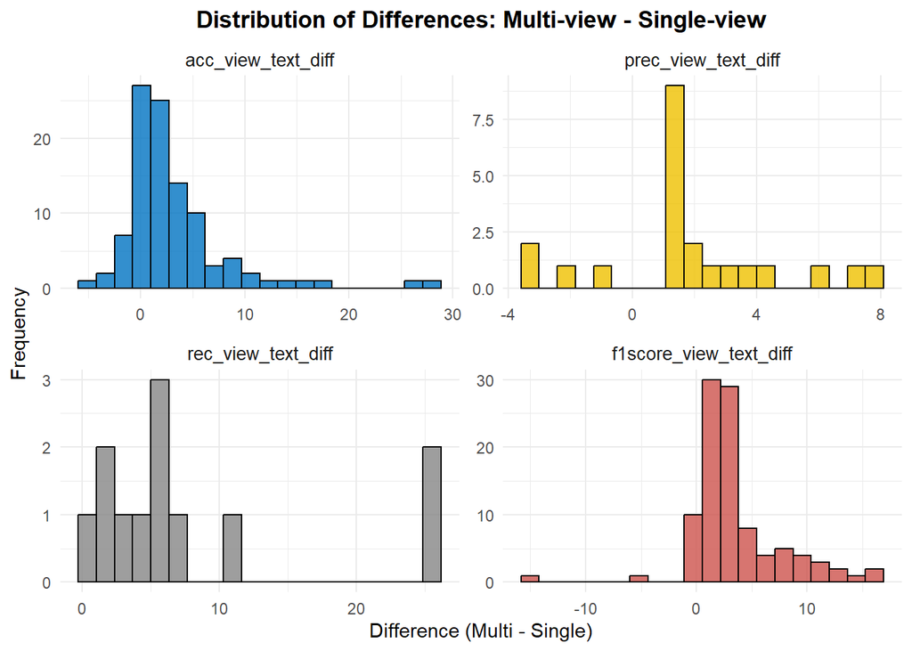

```r
global_palette <- stats::setNames(
  grDevices::colorRampPalette(ggsci::pal_jco("default")(8))(8),
  unique(long_diffs$metric_diff)
)

gplot <- ggplot(long_diffs, aes(x = diff, fill = metric_diff)) +
  geom_histogram(
    bins     = 20,
    color    = "black",
    position = "identity",
    alpha    = 0.8
  ) +
  facet_wrap(~ metric_diff,
             scales = "free",
             nrow   = 4,
             ncol   = 2) +
  scale_fill_manual(values = global_palette, guide  = FALSE) +
  labs(title = "Distribution of Differences: Multi-view − Single-view",
       x     = "Difference (Multi − Single)",
       y     = "Frequency") +
  theme_minimal() +
  theme(
    plot.title    = element_text(hjust = 0.5, face = "bold"),
    strip.text    = element_text(size = 10),
    panel.spacing = unit(0.5, "lines")
  )

gplot
```

Indicators values difference in form of box-plots.

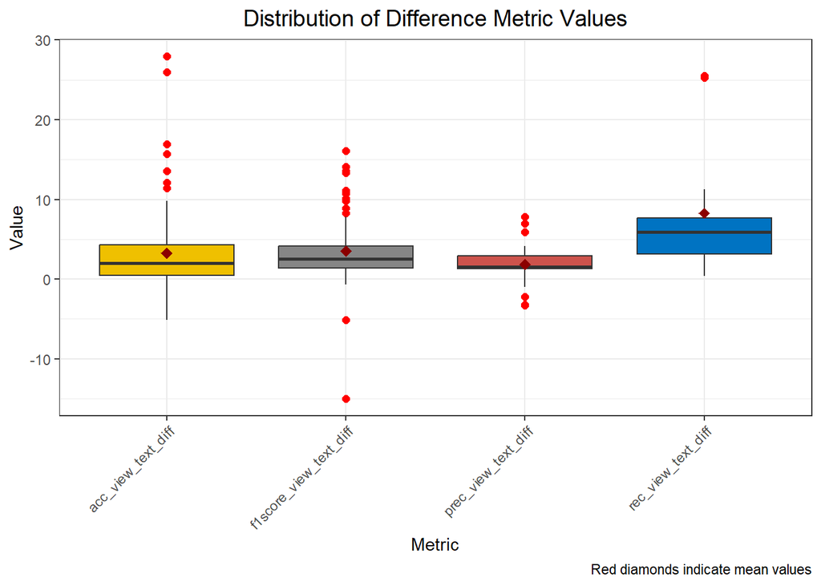

```r
df_long <- view_diffs %>%
  pivot_longer(cols = everything(),
               names_to = "Metric",
               values_to = "Value") %>%
  drop_na(Value)  # Remove rows with NA values

global_palette <- stats::setNames(
  grDevices::colorRampPalette(
    ggsci::pal_jco("default")(8))(8), unique(df_long$Metric))

# Create a box plot for each metric
ggplot(df_long, aes(x = Metric, y = Value, fill = Metric)) +
  geom_boxplot(outlier.color = "red", outlier.size = 2) +
  stat_summary(
    fun     = mean,
    geom    = "point",
    shape   = 18,
    size    = 3,
    color   = "darkred"
  ) +
  scale_fill_manual(values = global_palette) +
  theme_bw() +
  theme(
    axis.text.x  = element_text(angle = 45, hjust = 1),
    plot.title   = element_text(hjust = 0.5, size = 14),
    legend.position = "none"      # hide legend if you don't need it
  ) +
  labs(
    title   = "Distribution of Difference Metric Values",
    x       = "Metric",
    y       = "Value",
    caption = "Red diamonds indicate mean values"
  )
```

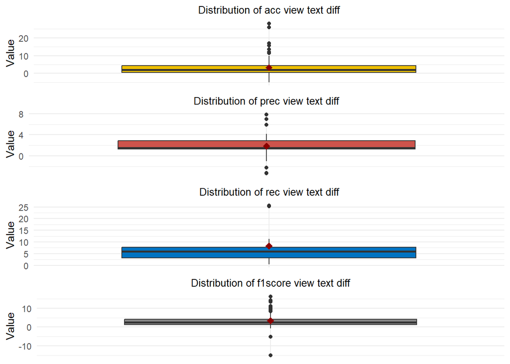

```r
# Build all plots and arrange as 4 rows × 2 columns
plot_list <- lapply(colnames(view_diffs), function(col)
  create_boxplot(view_diffs, col, global_palette))

grid.arrange(grobs = plot_list, ncol  = 1, nrow  = 4)
```

```r
stats_list <- summary_stats(view_diffs)

summary_df <- do.call(rbind, stats_list)
summary_df$Metric <- rownames(summary_df)
rownames(summary_df) <- NULL
```

```r
knitr::kable(summary_df[, c("Metric", "Count", "Min", "Max", "Mean", "Median", "SD")], caption = "Distribution of metrics in all works") %>% kableExtra::kable_styling()
```

Table 3.15: Table 3.16: Distribution of metrics in all works

| Metric | Count | Min | Max | Mean | Median | SD |
| --- | --- | --- | --- | --- | --- | --- |
| acc_view_text_diff | 101 | -5.11 | 27.98 | 3.267822 | 2.000 | 5.061075 |
| prec_view_text_diff | 22 | -3.30 | 7.80 | 1.865455 | 1.520 | 2.828556 |
| rec_view_text_diff | 12 | 0.40 | 25.50 | 8.277500 | 5.930 | 8.483150 |
| f1score_view_text_diff | 100 | -15.03 | 16.10 | 3.503300 | 2.525 | 4.228347 |